# RDA_model_within-population_and_evolutionary_responses_Ppinaster_study

# 6 Compute the optimal genomic composition

```r
list_models<- c("MIROC_ESM","IPSL_CM5A_LR","MPI_ESM_P","MRI_CGCM3","CNRM_CM5")

list_rda <- c("RDA_outliers_LC","RDA_outliers_MC","RDA_all_outliers_LC",'RDA_all_outliers_MC')
list_period <- c("Mid_Holo_6000_MIROC_ESM","Mid_Holo_6000_IPSL_CM5A_LR","Mid_Holo_6000_MPI_ESM_P","Mid_Holo_6000_MRI_CGCM3","Mid_Holo_6000_CNRM_CM5","past","present","future")#"LIG",
list_set <- c("LC","MC","all_outliers_LC","all_outliers_MC")

K=2 #Number of rda axes retained

for(i in 1: length(list_rda)){

  rda_model <- get(list_rda[i])
  set <- list_set[i]

  for(x in 1: length(list_period)){

  name <- list_period[x]

  if(name == "future"){

  for(a in 1:length(list_models_clim)){

  models_clim <- list_models_clim[a]
  clim <- get(paste0("clim_df_",name,"_scale_plots_",models_clim))
  predictions <- data.frame(Population=meta_data_plots$ID,predict(rda_model,clim, type = "lc", rank = K, scaling = "none"))
  assign(paste0("adaptive_values_",set,"_",name,"_",models_clim),predictions)
  }

  }else{

    clim <- get(paste0("clim_df_",name,"_scale_plots"))
  #Model
  predictions <- data.frame(Population=meta_data_plots$ID,predict(rda_model,clim, type = "lc", rank = K, scaling = "none"))

  assign(paste0("adaptive_values_",set,"_",name),predictions)

    }
  }
}
#Mean value for future across climatic models

K <- 2#Number of RDA axes

#Loop over SNP sets
for (set in list_set) {

  model_names <- list_models_clim

  #Initialise list to hold renamed data
  future_preds_list <- list()

  for (model in model_names) {

    #Get the object
    df <- get(paste0("adaptive_values_", set, "_future_", model))

    #Rename RDA columns to avoid name conflict
    new_colnames <- c("Population", paste0("RDA", 1:K, "_", model))
    colnames(df)[1:(K+1)] <- new_colnames  #Assumes population is first

    future_preds_list[[model]] <- df
  }

  #Merge all by population
  future_preds_merged <- Reduce(function(x, y) merge(x, y, by = "Population"), future_preds_list)

  #Compute mean RDA scores across models
  future_mean_df <- data.frame(
    Population = future_preds_merged$Population,
    sapply(1:K, function(k) {
      #Get all RDA_k_* columns
      cols_k <- grep(paste0("RDA", k, "_"), colnames(future_preds_merged), value = TRUE)
      rowMeans(future_preds_merged[, cols_k], na.rm = TRUE)
    })
  )

  colnames(future_mean_df)[-1] <- paste0("RDA", 1:K)

  #Save final result
  obj_name <- paste0("adaptive_values_", set, "_future_mean")
  assign(obj_name, future_mean_df)

  #Store the object name for later saving
  save(list = obj_name, file = paste0("Results/Chapter3/Pinaster/RDA_values/adaptive_values/adaptive_values_", set, "_future_mean.Rdata"))
}
```

Optimal values including mid-Holocene:

```r
list_models <- c("MIROC_ESM","IPSL_CM5A_LR","MPI_ESM_P","MRI_CGCM3","CNRM_CM5")

list_rda <- c("RDA_outliers_LC","RDA_outliers_MC","RDA_all_outliers_LC","RDA_all_outliers_MC")
list_period <- c("Mid_Holo_6000","past","present","future")#"LIG",
list_set <- c("LC","MC","all_outliers_LC","all_outliers_MC")

K <- 2

for (i in 1:length(list_rda)) {

  rda_model <- get(list_rda[i])
  set <- list_set[i]

  for (period in list_period) {

    if (period == "future") {

      for (model in list_models_clim) {

        clim <- get(paste0("clim_df_", period, "_scale_plots_", model))

        predictions <- data.frame(
          Population = meta_data_plots$ID,
          predict(rda_model, clim, type = "lc", rank = K, scaling = "none")
        )

        assign(
          paste0("adaptive_values_", set, "_", period, "_", model),
          predictions
        )
      }

    } else if (period == "Mid_Holo_6000") {

      for (model in list_models) {

        clim <- get(paste0("clim_df_", period, "_", model, "_scale_plots"))

        predictions <- data.frame(
          Population = meta_data_plots$ID,
          predict(rda_model, clim, type = "lc", rank = K, scaling = "none")
        )

        assign(
          paste0("adaptive_values_", set, "_", period, "_", model),
          predictions
        )
      }

    } else {

      clim <- get(paste0("clim_df_", period, "_scale_plots"))

      predictions <- data.frame(
        Population = meta_data_plots$ID,
        predict(rda_model, clim, type = "lc", rank = K, scaling = "none")
      )

      assign(
        paste0("adaptive_values_", set, "_", period),
        predictions
      )
    }
  }
}


for (set in list_set) {

  #FUTURE mean
  {
    preds_list <- list()

    for (model in list_models_clim) {

      df <- get(paste0("adaptive_values_", set, "_future_", model))

      colnames(df)[1:(K+1)] <- c("Population", paste0("RDA", 1:K, "_", model))

      preds_list[[model]] <- df
    }

    merged <- Reduce(function(x,y) merge(x,y,by="Population"), preds_list)

    future_mean_df <- data.frame(
      Population = merged$Population,
      sapply(1:K, function(k) {
        cols <- grep(paste0("RDA",k,"_"), colnames(merged), value=TRUE)
        rowMeans(merged[,cols], na.rm=TRUE)
      })
    )

    colnames(future_mean_df)[-1] <- paste0("RDA",1:K)

    obj_name <- paste0("adaptive_values_", set, "_future_mean")
    assign(obj_name, future_mean_df)

    save(list=obj_name,
         file=paste0("Results/Chapter3/Pinaster/RDA_values/adaptive_values/",obj_name,".Rdata"))
  }

  #MID HOLOCENE MEAN
  {
    preds_list <- list()

    for (model in list_models) {

      df <- get(paste0("adaptive_values_", set, "_Mid_Holo_6000_", model))

      colnames(df)[1:(K+1)] <- c("Population", paste0("RDA", 1:K, "_", model))

      preds_list[[model]] <- df
    }

    merged <- Reduce(function(x,y) merge(x,y,by="Population"), preds_list)

    mh_mean_df <- data.frame(
      Population = merged$Population,
      sapply(1:K, function(k) {
        cols <- grep(paste0("RDA",k,"_"), colnames(merged), value=TRUE)
        rowMeans(merged[,cols], na.rm=TRUE)
      })
    )

    colnames(mh_mean_df)[-1] <- paste0("RDA",1:K)

    obj_name <- paste0("adaptive_values_", set, "_Mid_Holo_6000_mean")
    assign(obj_name, mh_mean_df)

    save(list=obj_name,
         file=paste0("Results/Chapter3/Pinaster/RDA_values/adaptive_values/",obj_name,".Rdata"))
  }
}
```

## 6.1 Genomic data Lacanau and Tocchi individuals

We need to calculate RDA scores for each individual in the Lacanau and Tocchi populations, based on their genomic composition at loci associated with climate. First, we need to format their genomic data.

Load genomic data:

```r
load("Data/Chapter3/Pinus_pinaster/genomic_data_newpop/Adults_offsprings_merge_df/data_Lacanau_tot.Rdata")
colnames(data_Lacanau_tot) <- gsub("\\.", "", colnames(
  data_Lacanau_tot))

load("Data/Chapter3/Pinus_pinaster/genomic_data_newpop/Adults_offsprings_merge_df/data_Tocchi_tot.Rdata")
colnames(data_Tocchi_tot) <- gsub("\\.", "", colnames(data_Tocchi_tot))
```

We need to encode the SNPs in allelic frequency. To do this, we need to retrieve from the VCF which allele is the REF and which is the ALT, in order to match the REF and ALT used to build the GEA model. We should indeed use the same REF and ALT, otherwise, we will compare SNPs between the 82 range-wide populations from the model and the Lacanau and Tocchi individuals, which should not be compared as the information is displayed differently. We load the VCF with good genotypes (see the ‘Correcting_genotypes_pinaster_VCF’ script).

```r
vcf <- read.vcfR("Data/Chapter3/Pinus_pinaster/GEA_model_pinaster/Genomic_data/good_genotyped_comparison_LAC_TOC/Ppin_FRM_baseline_polymorphic_correct_REF_ALT.vcf", verbose = FALSE,convertNA=T)
```

**HTML users should refer to the script version to obtain the associated codes.**

Missing data is imputed using the most common genotype within the population, regardless of cohort, to avoid artificially inflating differences between cohorts:

```r
load("Data/Chapter3/Pinus_pinaster/GEA_model_pinaster/Genomic_data/good_genotyped_comparison_LAC_TOC/df_Lacanau_allelic_frequencies.Rdata")

load("Data/Chapter3/Pinus_pinaster/GEA_model_pinaster/Genomic_data/good_genotyped_comparison_LAC_TOC/df_Tocchi_allelic_frequencies.Rdata")
```

Keep only the climate-associated SNPs for each dataset:

```r
list_plots <- c("Lacanau","Tocchi")
list_SNP <- c("outliers_set_LC_common_final","outliers_set_MC_common_final","all_outliers_set_LC_common_unique_final","all_outliers_set_MC_common_unique_final")
list_name_snp <- c("LC","MC","all_outliers_LC","all_outliers_MC")

for(x in 1:length(list_plots)){

  plot <- list_plots[x]
  data <- get(paste0("df_",plot,"_allelic_frequencies"))

  for(i in 1: length(list_SNP)){

    snp_set <- list_SNP[i]
    name_set <- list_name_snp[i]
    snp_set <- get(snp_set)

    common_snps <- intersect(colnames(data[,-1]), snp_set)
    filtered_data <- data[, common_snps, drop = FALSE]

    #Assign the filtered dataframe to a variable with a descriptive name
    assign(paste0("data_", plot, "_", name_set), filtered_data)
  }
}
```

# 7 Compute individual scores for each Lacanau and Tocchi individuals

In this step, we compute the RDA scores for all sampled individuals in the two populations (Lacanau and Tocchi), using their allelic frequencies for climate-associated SNPs. This allows us to compare them in the RDA model with the optimum values for different time periods. Here, we use the predict function with the “wa” type and no scaling, matching the way the RDA values are obtained in the RDA model with the 82 range-wide populations (i.e. historical, past, present, and future optima).

```r
list_plots <- c("Lacanau","Tocchi")
list_SNP <- c("outliers_set_LC_common_final", "outliers_set_MC_common_final","all_outliers_set_LC_common_unique_final","all_outliers_set_MC_common_unique_final")
list_name_snp <- c("LC","MC","all_outliers_LC","all_outliers_MC")
list_rda <- c("RDA_outliers_LC","RDA_outliers_MC","RDA_all_outliers_LC",'RDA_all_outliers_MC')

for(x in 1: length(list_plots)){

  plot <- list_plots[x]
genomic_data <- get(paste0("df_",plot,"_allelic_frequencies"))

for(i in 1: length(list_rda)){

  rda_model <- get(list_rda[i])
  set <- get(list_SNP[i])
  name_snp <- list_name_snp[i]

 projected_scores <- predict(rda_model, newdata = genomic_data[set], type = "wa", rank = K, scaling = "none")#"none"

  assign(paste0("adaptive_values_",plot,"_",name_snp),projected_scores)
  }
}

write.csv(adaptive_values_Tocchi_all_outliers_MC, file="Results/Chapter3/Pinaster/Comparison_juveniles_adults/numbers/adaptive_values_Tocchi_all_outliers_MC.csv")
```

Use the Kinship test to identify the few juveniles in Tocchi who are closely related to the future optima.

# 8 Plot the results

We can analyse the results to compare the values of individuals within and between populations, as well as comparing them to the values of the other 82 populations across the range. We can also search for differences between cohorts.

Prepare the plottings:

```r
for(x in 1: length(list_plots)){

  plot <- list_plots[x]

for(i in 1: length(list_rda)){

  rda_model <- get(list_rda[i])
  set <- get(list_SNP[i])
  name_snp <- list_name_snp[i]

  #Adaptive value plots
  #adaptive_values_plot_LIG_origin <- get(paste0("adaptive_values_",name_snp,"_LIG_origin"))
  #adaptive_values_plot_Mid_Holo_6000_origin <- get(paste0("adaptive_values_",name_snp,"_Mid_Holo_6000_origin"))

  #adaptive_values_plot_LIG <- get(paste0("adaptive_values_",name_snp,"_LIG"))
  adaptive_values_plot_Mid_Holo_6000 <- get(paste0("adaptive_values_",name_snp,"_Mid_Holo_6000_mean"))
  adaptive_values_plot_past <- get(paste0("adaptive_values_",name_snp,"_past"))
  adaptive_values_plot_present <- get(paste0("adaptive_values_",name_snp,"_present"))
  adaptive_values_plot_future <- get(paste0("adaptive_values_",name_snp,"_future_mean"))

  #Adaptive value individuals
  adaptive_value_obs <- get(paste0("adaptive_values_",plot,"_",name_snp))
  }
}
```

Main figure, we flipped RDA2 all outlier MC to match the direction of the others but the information is unchanged.

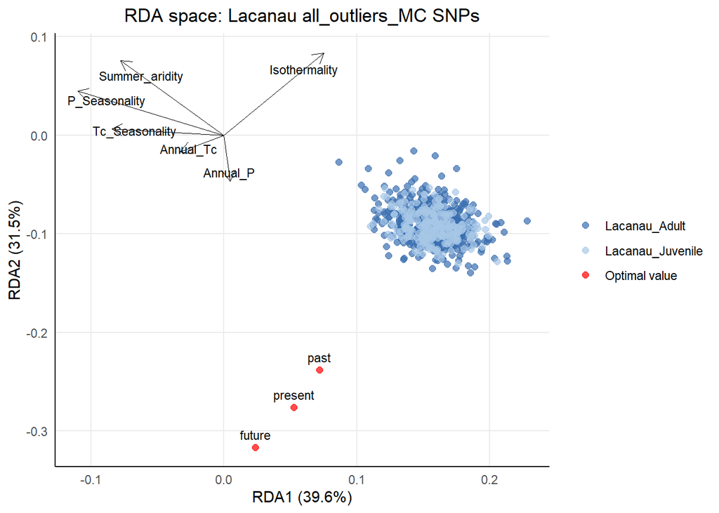

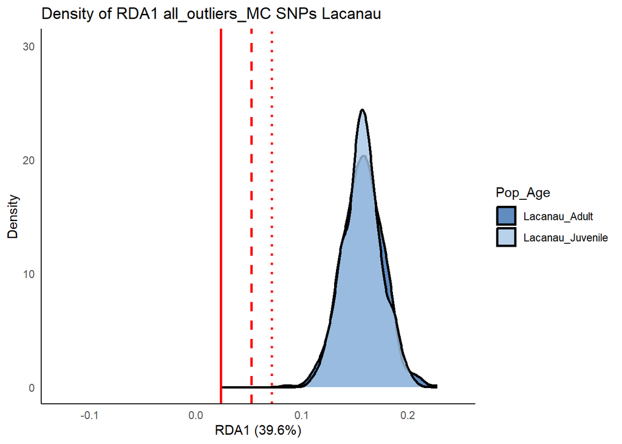

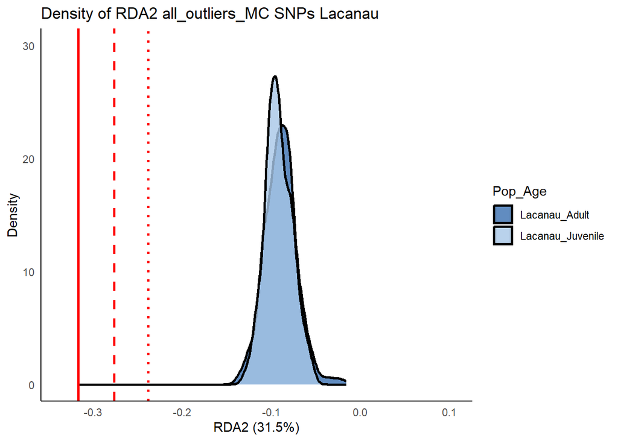

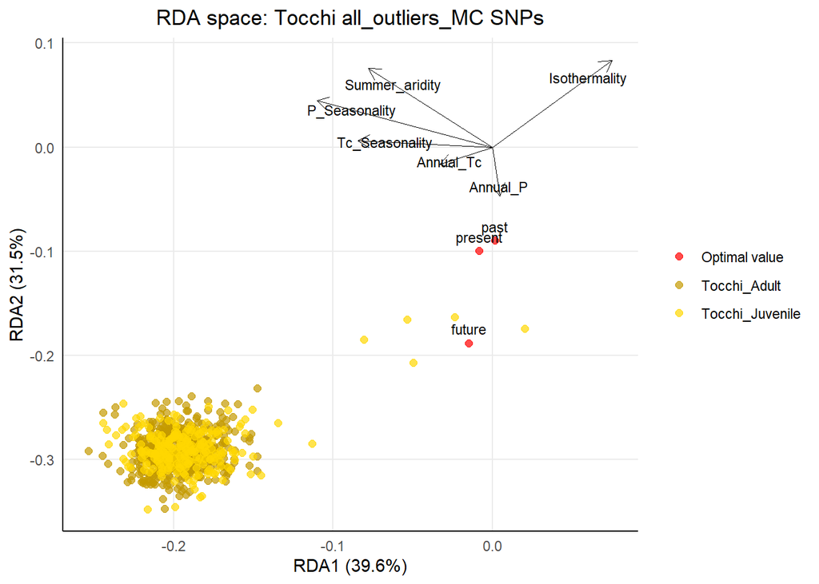

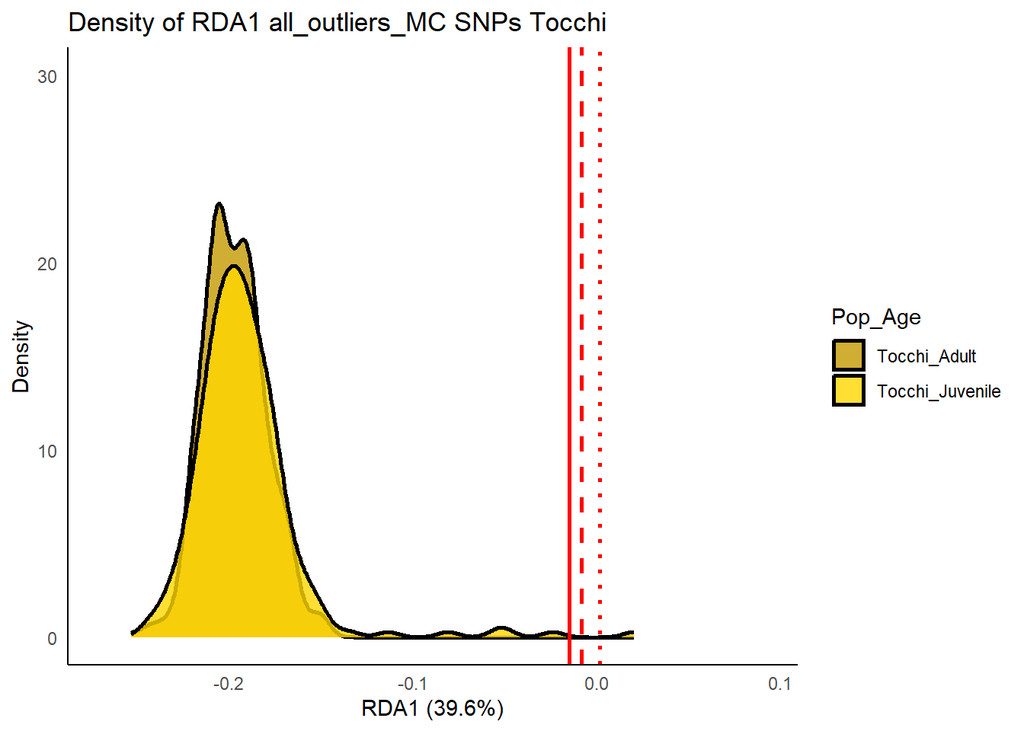

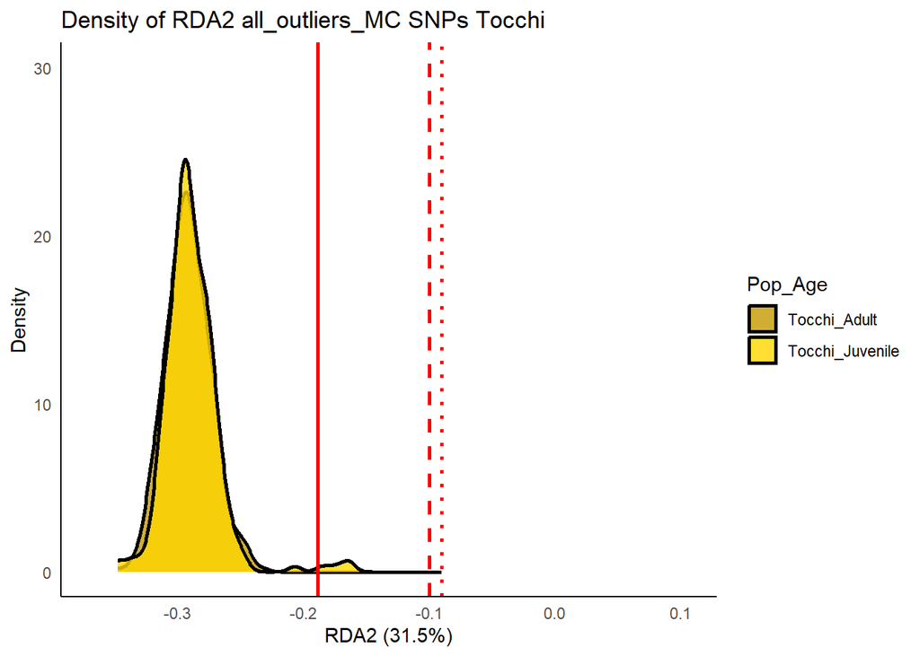

```r
#Flip RDA2 all_outlier MC
flip_if_needed <- function(x, flip) {
  if (flip) return(-x)
  return(x)
}

list_SNP_Rmarkdown <- c("all_outliers_set_MC_common_unique_final")
list_name_snp_Rmarkdown <- c("all_outliers_MC")
list_rda_Rmarkdown <- c("RDA_all_outliers_MC")

#Define color mapping for Population + Age
group_colors <- c(
  "Lacanau_Adult" = "#3A6FB0",
  "Lacanau_Juvenile" = "#A7C7E7",
  "Tocchi_Adult" = "#C49A00",
  "Tocchi_Juvenile" = "#FFD700",
  "Optimal value" = "red"
)

t_test_summary <- list()

#Precompute max density across all datasets for uniform y-axis
all_density_values <- c()

for (plot in list_plots) {
  for (i in 1:length(list_rda_Rmarkdown)) {

    flip_RDA2 <- list_rda_Rmarkdown[i] == "RDA_all_outliers_MC"

    #Observed adaptive values
    adaptive_value_obs <- get(paste0("adaptive_values_", plot, "_", list_name_snp_Rmarkdown[i]))
    adaptive_value_obs <- data.frame(
      ID = row.names(adaptive_value_obs),
      RDA1 = adaptive_value_obs[,1],
      RDA2 = adaptive_value_obs[,2]
    )

    #Assign Pop_Age
    adaptive_value_obs$Group <- "Adult"
    if (plot == "Lacanau") adaptive_value_obs$Group[grepl("^FR_PP", adaptive_value_obs$ID)] <- "Juvenile"
    if (plot == "Tocchi") adaptive_value_obs$Group[grepl("^IT_PP", adaptive_value_obs$ID)] <- "Juvenile"
    adaptive_value_obs$Pop_Age <- paste0(plot, "_", adaptive_value_obs$Group)

    #Present & future adaptive values
    adaptive_values_past<- get(paste0("adaptive_values_", list_name_snp_Rmarkdown[i], "_past"))
    adaptive_values_present <- get(paste0("adaptive_values_", list_name_snp_Rmarkdown[i], "_present"))
    adaptive_values_future  <- get(paste0("adaptive_values_", list_name_snp_Rmarkdown[i], "_future_mean"))

    adaptive_value_pres_fut <- rbind(
      adaptive_values_past,
      adaptive_values_present,
      adaptive_values_future
    )

    adaptive_value_pres_fut$Pop_Age <- "Optimal value"

    #Flip
    adaptive_value_obs$RDA2 <- flip_if_needed(adaptive_value_obs$RDA2, flip_RDA2)
    adaptive_value_pres_fut$RDA2 <- flip_if_needed(adaptive_value_pres_fut$RDA2, flip_RDA2)

    density_df <- rbind(
      adaptive_value_obs[, c("RDA1","RDA2","Pop_Age")],
      adaptive_value_pres_fut[, c("RDA1","RDA2","Pop_Age")]
    )
    density_df <- density_df[density_df$Pop_Age != "Optimal value", ]

    all_density_values <- c(all_density_values,
                            density(density_df$RDA1)$y,
                            density(density_df$RDA2)$y)
  }
}

max_density <- max(all_density_values) * 1.05

#Main loop
for (plot in list_plots) {

  for (i in 1:length(list_rda_Rmarkdown)) {

    rda_model <- get(list_rda_Rmarkdown[i])
    set <- get(list_SNP_Rmarkdown[i])
    name_snp <- list_name_snp_Rmarkdown[i]
    flip_RDA2 <- list_rda_Rmarkdown[i] == "RDA_all_outliers_MC"

    explained_variance_round <- round(rda_model$CCA$eig*100/sum(rda_model$CCA$eig), digits = 1)

    #Climatic arrows
    env_scores <- scores(rda_model, display = "bp")
    env_df <- as.data.frame(env_scores)
    env_df$Variable <- rownames(env_df)
    arrow_multiplier <- 0.15
    env_df$RDA1 <- env_df$RDA1 * arrow_multiplier
    env_df$RDA2 <- env_df$RDA2 * arrow_multiplier
    #flip
    env_df$RDA2 <- flip_if_needed(env_df$RDA2, flip_RDA2)

    #Adaptive values
    adaptive_values_past<- get(paste0("adaptive_values_", name_snp, "_past"))
    adaptive_values_present <- get(paste0("adaptive_values_", name_snp, "_present"))
    adaptive_values_future  <- get(paste0("adaptive_values_", name_snp, "_future_mean"))

    ids_plot <- grep(plot, adaptive_values_present$Population, value = TRUE)
    past_plot <- adaptive_values_past[adaptive_values_past$Population %in% ids_plot, ]
    present_plot <- adaptive_values_present[adaptive_values_present$Population %in% ids_plot, ]
    future_plot  <- adaptive_values_future[adaptive_values_future$Population %in% ids_plot, ]

    past_plot$Population <- paste0(past_plot$Population, "_past")
    present_plot$Population <- paste0(present_plot$Population, "_present")
    future_plot$Population  <- paste0(future_plot$Population, "_future")
    adaptive_value_pres_fut <- rbind(past_plot,present_plot, future_plot)
    adaptive_value_pres_fut$Group <- "Optimal value"
    adaptive_value_pres_fut$Pop_Age <- "Optimal value"
    adaptive_value_pres_fut$Time <- ifelse(
      grepl("_past$", adaptive_value_pres_fut$Population), "past",
      ifelse(
        grepl("_present$", adaptive_value_pres_fut$Population), "present",
        "future"
      )
    )
#Flip
    adaptive_value_pres_fut$RDA2 <- flip_if_needed(adaptive_value_pres_fut$RDA2, flip_RDA2)

    #Observed adaptive values
    adaptive_value_obs <- get(paste0("adaptive_values_", plot, "_", name_snp))
    adaptive_value_obs <- data.frame(
      ID = row.names(adaptive_value_obs),
      RDA1 = adaptive_value_obs[,1],
      RDA2 = adaptive_value_obs[,2]
    )

    #Assign group: Adult vs Juvenile
    adaptive_value_obs$Group <- "Adult"
    if (plot == "Lacanau") adaptive_value_obs$Group[grepl("^FR_PP", adaptive_value_obs$ID)] <- "Juvenile"
    if (plot == "Tocchi") adaptive_value_obs$Group[grepl("^IT_PP", adaptive_value_obs$ID)] <- "Juvenile"

    adaptive_value_obs$Pop_Age <- paste0(plot, "_", adaptive_value_obs$Group)

    #Flip
    adaptive_value_obs$RDA2 <- flip_if_needed(adaptive_value_obs$RDA2, flip_RDA2)

    #RDA plot
    combined_rda_data <- rbind(
      adaptive_value_obs[, c("ID","RDA1","RDA2","Pop_Age")],
      adaptive_value_pres_fut[, c("Population","RDA1","RDA2","Pop_Age")] %>% dplyr::rename(ID = Population)
    )

    rda1_limits <- range(combined_rda_data$RDA1, na.rm = TRUE)
    rda2_limits <- range(combined_rda_data$RDA2, na.rm = TRUE)

    #RDA scatter plot
    rda_plot <- ggplot(combined_rda_data, aes(x = RDA1, y = RDA2, color = Pop_Age)) +
      geom_point(alpha = 0.7, size = 2) +
      geom_text(data = combined_rda_data[combined_rda_data$Pop_Age == "Optimal value", ],
                aes(label = adaptive_value_pres_fut$Time),
                color = "black", size = 3, vjust = -0.8) +
      geom_segment(data = env_df, aes(x = 0, y = 0, xend = RDA1, yend = RDA2),
                   arrow = arrow(length = unit(0.3, "cm")), color = "black", size = 0.2) +
      geom_text(data = env_df, aes(x = RDA1*0.8, y = RDA2*0.8, label = Variable),
                color = "black", size = 3) +
      scale_color_manual(values = group_colors) +
      theme_minimal() +
      labs(title = paste("RDA space:", plot, name_snp, "SNPs"),
           x = paste0("RDA1 (", explained_variance_round[1], "%)"),
           y = paste0("RDA2 (", explained_variance_round[2], "%)")) +
      theme(legend.title = element_blank(),
            plot.title = element_text(hjust = 0.5),
            panel.grid.minor = element_blank(), axis.line = element_line(colour = "black"))
    print(rda_plot)

    built_rda <- ggplot_build(rda_plot)

    rda1_limits <- built_rda$layout$panel_params[[1]]$x.range
    rda2_limits <- built_rda$layout$panel_params[[1]]$y.range

    #Density plots
    density_df <- rbind(
      adaptive_value_obs[, c("RDA1","RDA2","Pop_Age")],
      adaptive_value_pres_fut[, c("RDA1","RDA2","Pop_Age")]
    )
    density_df_no_opt <- density_df[density_df$Pop_Age != "Optimal value", ]

    opt_RDA1_past <- adaptive_value_pres_fut$RDA1[adaptive_value_pres_fut$Time=="past"]
    opt_RDA1_present <- adaptive_value_pres_fut$RDA1[adaptive_value_pres_fut$Time=="present"]
    opt_RDA1_future  <- adaptive_value_pres_fut$RDA1[adaptive_value_pres_fut$Time=="future"]
    opt_RDA2_past <- adaptive_value_pres_fut$RDA2[adaptive_value_pres_fut$Time=="past"]
    opt_RDA2_present <- adaptive_value_pres_fut$RDA2[adaptive_value_pres_fut$Time=="present"]
    opt_RDA2_future  <- adaptive_value_pres_fut$RDA2[adaptive_value_pres_fut$Time=="future"]

    #RDA1 density plot
    density_plot_RDA1 <- ggplot(density_df_no_opt, aes(x = RDA1, fill = Pop_Age)) +
      geom_density(color = "black", alpha = 0.8, size = 1, cut = 10) +
      geom_vline(xintercept = opt_RDA1_past, linetype = "dotted", color = "red", size = 1) +
      geom_vline(xintercept = opt_RDA1_present, linetype = "dashed", color = "red", size = 1) +
      geom_vline(xintercept = opt_RDA1_future, linetype = "solid", color = "red", size = 1) +
      scale_fill_manual(values = group_colors) +
      coord_cartesian(xlim = rda1_limits, ylim = c(0, max_density+5))+
      labs(title = paste0("Density of RDA1 ", name_snp, " SNPs ", plot),
           x = paste0("RDA1 (", explained_variance_round[1], "%)"), y = "Density") +
      theme_minimal() +
      theme(panel.grid = element_blank(), axis.line = element_line(colour = "black"))

    print(density_plot_RDA1)

    #RDA2 density plot
    density_plot_RDA2 <- ggplot(density_df_no_opt, aes(x = RDA2, fill = Pop_Age)) +
      geom_density(color = "black", alpha = 0.8, size = 1, cut = 10) +
      geom_vline(xintercept = opt_RDA2_past, linetype = "dotted", color = "red", size = 1) +
      geom_vline(xintercept = opt_RDA2_present, linetype = "dashed", color = "red", size = 1) +
      geom_vline(xintercept = opt_RDA2_future, linetype = "solid", color = "red", size = 1) +
      scale_fill_manual(values = group_colors) +
      coord_cartesian(xlim = rda2_limits, ylim = c(0, max_density + 5))+
      labs(title = paste0("Density of RDA2 ", name_snp, " SNPs ", plot),
           x = paste0("RDA2 (", explained_variance_round[2], "%)"), y = "Density") +
      theme_minimal() +
      theme(panel.grid = element_blank(), axis.line = element_line(colour = "black"))

    print(density_plot_RDA2)
  }
}
```

Check if genetic shifts between adults and juveniles are significants using a t-test:

```r
t_test_summary <- list()

flip_if_needed <- function(x, flip) {
  if (flip) return(-x)
  return(x)
}

for (plot in list_plots) {

  for (i in 1:length(list_rda)) {

    rda_model <- get(list_rda[i])
    set <- get(list_SNP[i])
    name_snp <- list_name_snp[i]
    flip_RDA2 <- list_rda[i] == "RDA_all_outliers_MC"

    explained_variance_round <- round(rda_model$CCA$eig*100/sum(rda_model$CCA$eig), digits = 1)

    #Climatic arrows
    env_scores <- scores(rda_model, display = "bp")
    env_df <- as.data.frame(env_scores)
    env_df$Variable <- rownames(env_df)
    arrow_multiplier <- 0.15
    env_df$RDA1 <- env_df$RDA1 * arrow_multiplier
    env_df$RDA2 <- env_df$RDA2 * arrow_multiplier
    env_df$RDA2 <- flip_if_needed(env_df$RDA2, flip_RDA2)

    #Adaptive values
    adaptive_values_present <- get(paste0("adaptive_values_", name_snp, "_present"))
    adaptive_values_future <- get(paste0("adaptive_values_", name_snp, "_future_mean"))

    ids_plot <- grep(plot, adaptive_values_present$Population, value = TRUE)
    present_plot <- adaptive_values_present[adaptive_values_present$Population %in% ids_plot, ]
    future_plot <- adaptive_values_future[adaptive_values_future$Population %in% ids_plot, ]

    #Merge present & future
    present_plot$Population <- paste0(present_plot$Population, "_present")
    future_plot$Population <- paste0(future_plot$Population, "_future")
    adaptive_value_pres_fut <- rbind(present_plot, future_plot)
    adaptive_value_pres_fut$Group <- "Optimal value"
    adaptive_value_pres_fut$Pop_Age <- "Optimal value"  # for consistent rbind
    adaptive_value_pres_fut$Time <- ifelse(grepl("_present$", adaptive_value_pres_fut$Population), "present", "future")

    adaptive_value_pres_fut$RDA2 <- flip_if_needed(adaptive_value_pres_fut$RDA2, flip_RDA2)

    #Observed adaptive values
    adaptive_value_obs <- get(paste0("adaptive_values_", plot, "_", name_snp))
    adaptive_value_obs <- data.frame(
      ID = row.names(adaptive_value_obs),
      RDA1 = adaptive_value_obs[,1],
      RDA2 = adaptive_value_obs[,2]
    )

    #Assign group: Adult vs Juvenile
    adaptive_value_obs$Group <- "Adult"
    if (plot == "Lacanau") adaptive_value_obs$Group[grepl("^FR_PP", adaptive_value_obs$ID)] <- "Juvenile"
    if (plot == "Tocchi") adaptive_value_obs$Group[grepl("^IT_PP", adaptive_value_obs$ID)] <- "Juvenile"

    adaptive_value_obs$Pop_Age <- paste0(plot, "_", adaptive_value_obs$Group)

    adaptive_value_obs$RDA2 <- flip_if_needed(adaptive_value_obs$RDA2, flip_RDA2)

    #RDA plots
    combined_rda_data <- rbind(
      adaptive_value_obs[, c("ID","RDA1","RDA2","Pop_Age")],
      adaptive_value_pres_fut[, c("Population","RDA1","RDA2","Pop_Age")] %>%
        dplyr::rename(ID = Population)
    )

    #Combine for density: only Adults & Juveniles
    density_df <- rbind(
      adaptive_value_obs[, c("RDA1","RDA2","Pop_Age")],
      adaptive_value_pres_fut[, c("RDA1","RDA2","Pop_Age")]
    )
    density_df <- density_df[density_df$Pop_Age != "Optimal value", ]

    #T-test
    df_ttest <- density_df
    for (axis in c("RDA1", "RDA2")) {
      ttest <- t.test(as.formula(paste(axis, "~ Pop_Age")), data = df_ttest)
      t_test_summary[[length(t_test_summary)+1]] <- data.frame(
        Plot = plot,
        SNP_Set = name_snp,
        Axis = axis,
        t_statistic = ttest$statistic,
        p_value = ttest$p.value,
        mean_juvenile = mean(df_ttest[[axis]][df_ttest$Pop_Age %in% paste0(plot,"_Juvenile")], na.rm = TRUE),
        mean_adult = mean(df_ttest[[axis]][df_ttest$Pop_Age %in% paste0(plot,"_Adult")], na.rm = TRUE)
      )
    }

  }
}

#Combine t-test results
t_test_results_df <- do.call(rbind, t_test_summary)
print(t_test_results_df)
```

```
##        Plot         SNP_Set Axis t_statistic      p_value mean_juvenile
## t   Lacanau              LC RDA1  -1.2161057 0.2244667324   0.185189524
## t1  Lacanau              LC RDA2   2.1897297 0.0289629043  -0.012187716
## t2  Lacanau all_outliers_LC RDA1   3.7766923 0.0001773819   0.158934059
## t3  Lacanau all_outliers_LC RDA2   1.5609061 0.1191089257  -0.042659963
## t4  Lacanau              MC RDA1  -1.5966528 0.1109038481   0.212391191
## t5  Lacanau              MC RDA2   0.1992668 0.8421259271  -0.048738231
## t6  Lacanau all_outliers_MC RDA1   0.1676085 0.8669538298   0.157013335
## t7  Lacanau all_outliers_MC RDA2   2.0447584 0.0413207462  -0.091833898
## t8   Tocchi              LC RDA1  -1.5158349 0.1303839021  -0.034533497
## t9   Tocchi              LC RDA2  -3.0921271 0.0021288540  -0.334853332
## t10  Tocchi all_outliers_LC RDA1  -3.1188535 0.0019845372  -0.150640267
## t11  Tocchi all_outliers_LC RDA2  -2.4891095 0.0132401945  -0.310101372
## t12  Tocchi              MC RDA1  -1.5594516 0.1196014723  -0.002335401
## t13  Tocchi              MC RDA2  -2.5457804 0.0112147123  -0.310436838
## t14  Tocchi all_outliers_MC RDA1  -2.6711967 0.0079320213  -0.191631723
## t15  Tocchi all_outliers_MC RDA2  -1.7462298 0.0815234155  -0.288710678
##       mean_adult
## t    0.182850872
## t1  -0.008513199
## t2   0.163251175
## t3  -0.041172795
## t4   0.206935851
## t5  -0.048108218
## t6   0.157252281
## t7  -0.089268613
## t8  -0.037394660
## t9  -0.341581296
## t10 -0.156049927
## t11 -0.314337973
## t12 -0.007682155
## t13 -0.318393038
## t14 -0.197107558
## t15 -0.291636001
```